```python
from skmisc.loess import loess
import pandas as pd
from sklearn.cluster import KMeans
from sklearn.preprocessing import SplineTransformer
import numpy as np
import scipy as sp
import math
import matplotlib.pyplot as plt
from scipy.interpolate import splev, interp1d
import seaborn as sns
from random import seed
seed(3604)
```

Zeyu Liao(zeyu9, 667691486, MCS) Lu,Yangliang (yl164 661963604 MCS) Zexi Yan(zexiyan2, 651826615) MCS) Zeyu contributed to the implementation of Part 1 Yangliang contributed to the implementation of Part 2 Zexi contributed to the implementation of Part 3

# LOESS

```python
df = pd.read_csv('Coding3_data.csv')
```

```python
class myLoess(object):
    def __init__(self, x, y):
        min_v = np.min(x)
        max_v = np.max(x)
        self.x, self.min_x, self.max_x = (x - min_v)\
        / (max_v - min_v), min_v, max_v
#         min_v = np.min(yy)
#         max_v = np.max(yy)
        self.y, self.min_y, self.max_y = (y - min_v)\
        / (max_v - min_v), min_v, max_v


    def eval_est(self, x, W):
        xx = (x - self.min_x) /(self.max_x -self.min_x)
        a = np.abs(self.x - xx)
        rrange = self.dis_min(a, W)
        max_dist = np.max(a[rrange])
        a =a[rrange] / max_dist
        ww = np.zeros_like(a)
        idx = (a >= -1) & (a<= 1)
        ww[idx] = np.power(1.0 - np.power(np.abs(a[idx]), 3), 3)
        wo = np.ones((W, 1))
        wm = np.multiply(np.eye(W), ww)
        pp = np.array([[math.pow(xx, p)] for p in range(1)])
        ym = self.y[rrange]
        p = np.transpose(wo)@ wm
        j = np.linalg.pinv(p @ wo)@ p@ ym
        return (((j@ pp)[0]) * (self.max_y - self.min_y)) + self.min_y

    @staticmethod
    def dis_min(d, W):
        l = len(d)
        idx = np.argmin(d)
        if idx == 0:
            return np.arange(0, W)
        if idx == l-1:
            return np.arange(l - W, l)
        a = [idx]
        while len(a) < W:
            i = a[0]
            j = a[-1]
            if i == 0:
                a.append(j + 1)
            elif j == l-1:
                a.insert(0, i - 1)
            elif d[i-1] < d[j+1]:
                a.insert(0, i - 1)
            else:
                a.append(j + 1)
        return np.array(a)

    def smoother_diagonal(self,span):
        span = int(span)
        n = len(self.x)
        diagonal = np.zeros((n, 1))
        xx = (self.x - self.min_x) / (self.max_x - self.min_x)
        a = np.abs(self.x - xx)
        rrange = self.dis_min(a, span)
        max_dist = np.max(a[rrange])
#         print("a[rrange]:", a[rrange] )
        a = a[rrange] / max_dist
        ww = np.zeros_like(a)
        idx = (a >= -1) & (a <= 1)
        ww[idx] = np.power(1.0 - np.power(np.abs(a[idx]), 3), 3)
        wo = np.ones((len(rrange), 1))
        wm = np.multiply(np.eye(len(rrange)), ww)
        diagonal[rrange] = np.sum(wo.T @ wm @ wo, axis=1).reshape(-1, 1)
#         print("x:", xx)
#         print("rrange", rrange)
#         print("max_dist:", max_dist)
#         print("wo:", wo)
#         print("wm:", wm)
#         print("diagonal:", diagonal)

        return diagonal
```

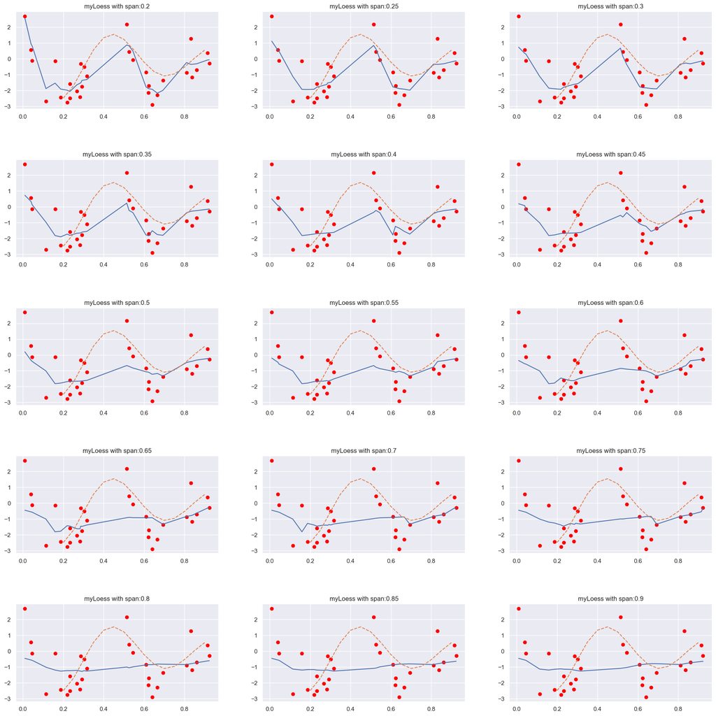

```python
# Use code from PSL: Smoothing Splines
fig, axes  = plt.subplots(5,3, figsize=(20, 20))
z = 0
k = 0

def f(x):
    return np.sin(12 * (x + 0.2)) / (x + 0.2)
fx = np.arange(0.20, 0.95, 0.05)
fy = f(fx)
for i in np.arange(0.20, 0.95, 0.05):
    i = np.round(i,2)
    val = {}
    if z==3:
        k+=1
        z=0
    for j in df.x:
        xx = df.x[(df.x >= j -(i/2)) & \
                  (df.x <= j +(i/2))]
        yy = df.y[(df.x >= j -(i/2)) & \
                  (df.x <= j +(i/2))]
        l = myLoess(xx.tolist(), yy.tolist())
        y = l.eval_est(j, len(xx))
        val.update({j:y})
    sns.set()
    axes[k][z].plot(val.keys(), val.values())
    axes[k][z].scatter(df.x, df.y, c='red')
    axes[k][z].plot(fx, fy, '--')
    axes[k][z].set_title(f'myLoess with span:{i}')
    fig.tight_layout(pad=5)
    z+=1
plt.show()
```

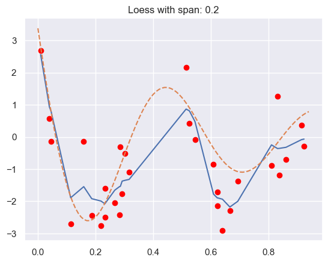

```python
def f(x):
    return np.sin(12 * (x + 0.2)) / (x + 0.2)
fx = np.arange(0, 0.95, 0.01)
fy = f(fx)
i = 0.2
val = {}
for j in df.x:
    xx = df.x[(df.x >= j -(i/2)) & \
              (df.x <= j +(i/2))]
    yy = df.y[(df.x >= j -(i/2)) & \
              (df.x <= j +(i/2))]
    l = myLoess(xx.tolist(), yy.tolist())
    y = l.eval_est(j, len(xx))
    val.update({j:y})

plt.plot(val.keys(), val.values())
plt.scatter(df.x, df.y, c='red')
plt.plot(fx, fy, '--')
plt.title('Loess with span: 0.2')
plt.show()
```

```python
from patsy import cr
def smootherm(x, a, b):
    xx = x[(x >= (b - (a/ 2))) & (x <=(b+ (a/2)))]
    y = np.zeros(len(xx))
    idx = xx.tolist().index(b)
    y[idx] = 1
    a = cr(xx, len(xx), constraints="center")
    trace = np.trace(a)
    ssum = np.sum(y.dot(a))
    return trace, ssum
```

```python
def CV_GCV(i):
    val = {}
    for j in df.x:
        xx = df.x[(df.x >= j -(i/2)) & \
                  (df.x <= j +(i/2))]
        yy = df.y[(df.x >= j -(i/2)) & \
                  (df.x <= j +(i/2))]
        l = myLoess(xx.tolist(), yy.tolist())
        y = l.eval_est(j, len(xx))
        val.update({j:y})

    CV = []
    GCV = []
    for k in df.x:
        trace, ssum = smootherm(df.x, i, k)
        CV_m = np.mean((np.subtract(list(val.values()), df.y.tolist())/(1-ssum))**2)
        CV.append(CV_m)
        GCV_m = np.mean((np.subtract(list(val.values()), df.y.tolist())/(1-trace/len(df.x)))**2)
        GCV.append(GCV_m)
    return np.mean(CV), np.mean(GCV)
# def GCV(i):
#     val = {}
#     for j in df.x:
#         xx = df.x[(df.x >= j -(i/2)) & \
#                   (df.x <= j +(i/2))]
#         yy = df.y[(df.x >= j -(i/2)) & \
#                   (df.x <= j +(i/2))]
#         l = myLoess(xx.tolist(), yy.tolist())
#         y = l.eval_est(j, len(xx))
#         val.update({j:y})
#     GCV = []
#     for k in df.x:
#         trace, ssum = smootherm(df.x, i, k)
#         GCV_m = np.mean((np.subtract(list(val.values()), df.y.tolist())/(1-trace/len(df.x)))**2)
#         GCV.append(GCV_m)
#     return np.mean(CV), np.mean(GCV)
```

```python
CV = [CV_GCV(i)[0] for i in np.arange(0.20, 0.95, 0.05)]
GCV = [CV_GCV(i)[1] for i in np.arange(0.20, 0.95, 0.05)]
data = {'CV':CV,
        'GCV': GCV,
        'span':  np.arange(0.20, 0.95, 0.05)}
result = pd.DataFrame(data)
result
```

|  | CV | GCV | span |
| --- | --- | --- | --- |
| 0 | 7.094994 | 0.735851 | 0.20 |
| 1 | 3.326996 | 1.006344 | 0.25 |
| 2 | 3.338326 | 1.152951 | 0.30 |
| 3 | 2.385170 | 1.367912 | 0.35 |
| 4 | 3.092015 | 1.731826 | 0.40 |
| 5 | 3.041023 | 1.986886 | 0.45 |
| 6 | 3.645789 | 2.261569 | 0.50 |
| 7 | 3.733790 | 2.565587 | 0.55 |
| 8 | 4.286362 | 3.019136 | 0.60 |
| 9 | 4.307208 | 3.409849 | 0.65 |
| 10 | 3.864545 | 3.866982 | 0.70 |
| 11 | 3.775227 | 4.002227 | 0.75 |
| 12 | 4.078721 | 4.492037 | 0.80 |
| 13 | 3.833209 | 4.877595 | 0.85 |
| 14 | 3.791642 | 5.130355 | 0.90 |

```python
print(result[result.CV == min(result.CV)])
print(result[result.GCV == min(result.GCV)])
```

```
        CV       GCV  span
3  2.38517  1.367912  0.35
         CV       GCV  span
0  7.094994  0.735851   0.2
```

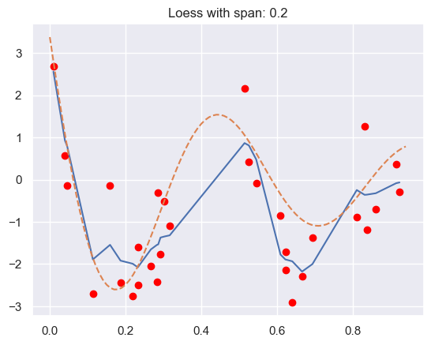

```python
def f(x):
    return np.sin(12 * (x + 0.2)) / (x + 0.2)
fx = np.arange(0, 0.95, 0.01)
fy = f(fx)
i = 0.2
val = {}
for j in df.x:
    xx = df.x[(df.x >= j -(i/2)) & \
              (df.x <= j +(i/2))]
    yy = df.y[(df.x >= j -(i/2)) & \
              (df.x <= j +(i/2))]
    l = myLoess(xx.tolist(), yy.tolist())
    y = l.eval_est(j, len(xx))
    val.update({j:y})

plt.plot(val.keys(), val.values())
plt.scatter(df.x, df.y, c='red')
plt.plot(fx, fy, '--')
plt.title('Loess with span: 0.2')
plt.show()
```

```python
from skmisc.loess import loess
def smoother(s):
    model = loess(df.x, df.y,span = s)
    model.fit()
    return model.outputs.diagonal

def cv_gcv(span):
    CVs = []
    GCVs = []
    n = len(df.x)
    model = loess(df.x, df.y)
    model.fit()
    pred = model.predict(df.x).values
    diagonal = smoother(span)
    cv = ((df.y - pred) /(1 - diagonal)) ** 2
    CVs.append(np.sum(cv)/ n)
    gcv = ((df.y-pred) / (1 - (np.sum(diagonal) / n)))** 2
    GCVs.append(np.sum(gcv)/ n)
    return np.mean(CVs), np.mean(GCVs)
```

```python
print(result[result.CV == min(result.CV)])
print(result[result.GCV == min(result.GCV)])
```

```
        CV       GCV  span
3  2.38517  1.367912  0.35
         CV       GCV  span
0  7.094994  0.735851   0.2
```

```python
CV= [cv_gcv(i)[0] for i in np.arange(0.20, 0.95, 0.05)]
GCV= [cv_gcv(i)[1] for i in np.arange(0.20, 0.95, 0.05)]
data = {'CV':CV,
        'GCV': GCV,
        'span':  np.arange(0.20, 0.95, 0.05)}
result = pd.DataFrame(data)
result
```

|  | CV | GCV | span |
| --- | --- | --- | --- |
| 0 | 743.347336 | 9.315396 | 0.20 |
| 1 | 18.084581 | 5.227782 | 0.25 |
| 2 | 7.427151 | 3.308671 | 0.30 |
| 3 | 3.895770 | 2.786091 | 0.35 |
| 4 | 2.941613 | 2.353919 | 0.40 |
| 5 | 2.781462 | 2.199077 | 0.45 |
| 6 | 2.471361 | 2.027046 | 0.50 |
| 7 | 2.122396 | 1.857042 | 0.55 |
| 8 | 2.072970 | 1.815976 | 0.60 |
| 9 | 1.937473 | 1.741796 | 0.65 |
| 10 | 1.687337 | 1.668900 | 0.70 |
| 11 | 1.636175 | 1.627429 | 0.75 |
| 12 | 1.607360 | 1.603860 | 0.80 |
| 13 | 1.576448 | 1.577274 | 0.85 |
| 14 | 1.562432 | 1.563959 | 0.90 |

```python
print(result[result.CV == min(result.CV)])
print(result[result.GCV == min(result.GCV)])
```

```
          CV       GCV  span
14  1.562432  1.563959   0.9
          CV       GCV  span
14  1.562432  1.563959   0.9
```

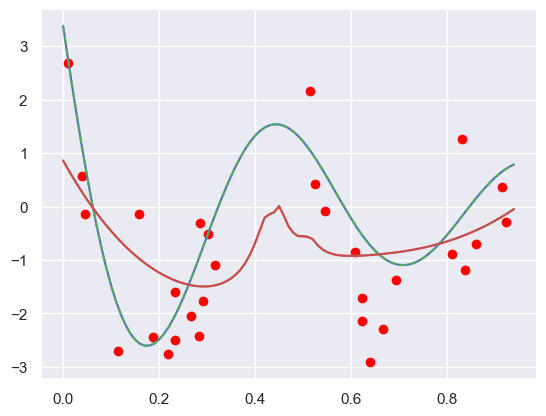

```python
def f(x):
    return np.sin(12 * (x + 0.2)) / (x + 0.2)
fx = np.arange(0, 0.95, 0.01)
fy = f(fx)
plt.plot(fx, fy, label="true plot")
y = loess(df.x, df.y, span=0.9, surface='direct').predict(fx).values
plt.plot(fx, y, label="loocv")
plt.scatter(df.x, df.y, c='red')
plt.plot(fx, fy, '--')
yy = loess(df.x, df.y, span=0.9, surface='direct').predict(fx).values
plt.plot(fx, yy, label="gcv")
plt.show()
```

PART II Clustering

```python
df = pd.read_csv('./Sales_Transactions_Dataset_Weekly.csv')
df.head()
```

|  | Product_Code | W0 | W1 | W2 | W3 | W4 | W5 | W6 | W7 | W8 | ... | Normalized 42 | Normalized 43 | Normalized 44 | Normalized 45 | Normalized 46 | Normalized 47 | Normalized 48 | Normalized 49 | Normalized 50 | Normalized 51 |
| --- | --- | --- | --- | --- | --- | --- | --- | --- | --- | --- | --- | --- | --- | --- | --- | --- | --- | --- | --- | --- | --- |
| 0 | P1 | 11 | 12 | 10 | 8 | 13 | 12 | 14 | 21 | 6 | ... | 0.06 | 0.22 | 0.28 | 0.39 | 0.50 | 0.00 | 0.22 | 0.17 | 0.11 | 0.39 |
| 1 | P2 | 7 | 6 | 3 | 2 | 7 | 1 | 6 | 3 | 3 | ... | 0.20 | 0.40 | 0.50 | 0.10 | 0.10 | 0.40 | 0.50 | 0.10 | 0.60 | 0.00 |
| 2 | P3 | 7 | 11 | 8 | 9 | 10 | 8 | 7 | 13 | 12 | ... | 0.27 | 1.00 | 0.18 | 0.18 | 0.36 | 0.45 | 1.00 | 0.45 | 0.45 | 0.36 |
| 3 | P4 | 12 | 8 | 13 | 5 | 9 | 6 | 9 | 13 | 13 | ... | 0.41 | 0.47 | 0.06 | 0.12 | 0.24 | 0.35 | 0.71 | 0.35 | 0.29 | 0.35 |
| 4 | P5 | 8 | 5 | 13 | 11 | 6 | 7 | 9 | 14 | 9 | ... | 0.27 | 0.53 | 0.27 | 0.60 | 0.20 | 0.20 | 0.13 | 0.53 | 0.33 | 0.40 |

5 rows × 107 columns

```python
# Normalize each time series by removing its mean. Store the de-meaned data in an 811-by-52 matrix X.
df_norm = df.copy()[df.columns[1:53]]
df_norm = df_norm.sub(df_norm.mean(axis=1), axis=0)
```

```python
# converted from R's ns()
def ns(x, df=None, knots=None, boundary_knots=None, include_intercept=False):
    degree = 3

    if boundary_knots is None:
        boundary_knots = [np.min(x), np.max(x)]
    else:
        boundary_knots = np.sort(boundary_knots).tolist()

    oleft = x < boundary_knots[0]
    oright = x > boundary_knots[1]
    outside = oleft | oright
    inside = ~outside

    if df is not None:
        nIknots = df - 1 - include_intercept
        if nIknots < 0:
            nIknots = 0

        if nIknots > 0:
            knots = np.linspace(0, 1, num=nIknots + 2)[1:-1]
            knots = np.quantile(x[~outside], knots)

    Aknots = np.sort(np.concatenate((boundary_knots * 4, knots)))
    n_bases = len(Aknots) - (degree + 1)

    if any(outside):
        basis = np.empty((x.shape[0], n_bases), dtype=float)
        e = 1 / 4 # in theory anything in (0, 1); was (implicitly) 0 in R <= 3.2.2

        if any(oleft):
            k_pivot = boundary_knots[0]
            xl = x[oleft] - k_pivot
            xl = np.c_[np.ones(xl.shape[0]), xl]

            # equivalent to splineDesign(Aknots, rep(k.pivot, ord), ord, derivs)
            tt = np.empty((xl.shape[1], n_bases), dtype=float)
            for j in range(xl.shape[1]):
                for i in range(n_bases):
                    coefs = np.zeros((n_bases,))
                    coefs[i] = 1
                    tt[j, i] = splev(k_pivot, (Aknots, coefs, degree), der=j)

            basis[oleft, :] = xl @ tt

        if any(oright):
            k_pivot = boundary_knots[1]
            xr = x[oright] - k_pivot
            xr = np.c_[np.ones(xr.shape[0]), xr]

            tt = np.empty((xr.shape[1], n_bases), dtype=float)
            for j in range(xr.shape[1]):
                for i in range(n_bases):
                    coefs = np.zeros((n_bases,))
                    coefs[i] = 1
                    tt[j, i] = splev(k_pivot, (Aknots, coefs, degree), der=j)

            basis[oright, :] = xr @ tt

        if any(inside):
            xi = x[inside]
            tt = np.empty((len(xi), n_bases), dtype=float)
            for i in range(n_bases):
                coefs = np.zeros((n_bases,))
                coefs[i] = 1
                tt[:, i] = splev(xi, (Aknots, coefs, degree))

            basis[inside, :] = tt
    else:
        basis = np.empty((x.shape[0], n_bases), dtype=float)
        for i in range(n_bases):
            coefs = np.zeros((n_bases,))
            coefs[i] = 1
            basis[:, i] = splev(x, (Aknots, coefs, degree))

    const = np.empty((2, n_bases), dtype=float)
    for i in range(n_bases):
        coefs = np.zeros((n_bases,))
        coefs[i] = 1
        const[:, i] = splev(boundary_knots, (Aknots, coefs, degree), der=2)

    if include_intercept is False:
        basis = basis[:, 1:]
        const = const[:, 1:]

    qr_const = np.linalg.qr(const.T, mode='complete')[0]
    basis = (qr_const.T @ basis.T).T[:, 2:]

    return basis
```

Fit each time series with an NCS with df = 10. This corresponds to an NCS with 8 interior knots. Each row of X_811×52 represents the response, with the 1-dimensional feature being the index from 1 to 52.

```python
# Fit each time series with an NCS with df = 10. This corresponds to an NCS with 8 interior knots.
X = df_norm.values
X.shape
```

```
(811, 52)
```

```python
# F is a 52-by-9 design matrix without the intercept. For instance, this can be obtained using the ns function.
# Remove the column mean from F to disregard the intercept.
F = ns(np.arange(1, 53), df=9, include_intercept=False)
F -= F.mean(axis=0)
F.shape
```

```
(52, 9)
```

```python
# Calculate Coefficients B
FtF_inv = np.linalg.inv(F.T @ F)
FtF_inv_Ft = FtF_inv @ F.T
Bt = FtF_inv_Ft @ X.T
Bt.shape
```

```
(9, 811)
```

```python
B = Bt.T
```

```python
from sklearn.cluster import KMeans
kmeans = KMeans(n_clusters=6, random_state=0, max_iter=300).fit(B)
center = kmeans.cluster_centers_
```

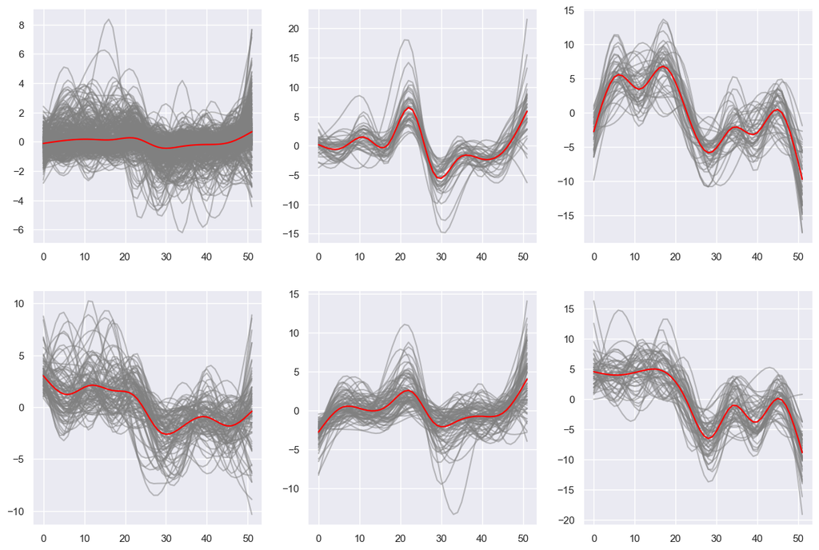

```python
# Visualize the centered time series (colored in grey) of products grouped by their clusters. Overlay
# the plots with the cluster centers (colored in red). Arrange the visualizations in a 2-by-3 format.
fig, axs = plt.subplots(2, 3, figsize=(15, 10))
for i in range(6):
    idx = np.where(kmeans.labels_ == i)[0]
    for j in range(len(idx)):
        axs[i // 3, i % 3].plot(F @ B[idx[j], :], color='grey', alpha=0.5)
    axs[i // 3, i % 3].plot(F @ center[i, :], color='red')
```

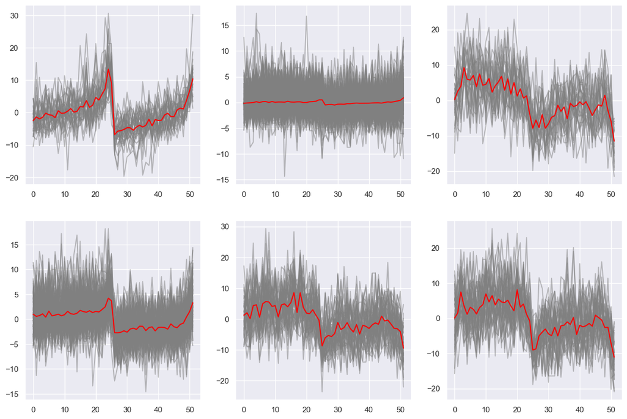

```python
kmeans = KMeans(n_clusters=6, random_state=0).fit(X)
center = kmeans.cluster_centers_
fig, axs = plt.subplots(2, 3, figsize=(15, 10))
for i in range(6):
    idx = np.where(kmeans.labels_ == i)[0]
    for j in range(len(idx)):
        axs[i // 3, i % 3].plot(X[idx[j], :], color='grey', alpha=0.5)
    axs[i // 3, i % 3].plot(center[i, :], color='red')
```

# PART III Regression Splines

```python
from sklearn.linear_model import LinearRegression
# ref: https://github.com/pydata/patsy/blob/6bd31ca7f5f12e77a918681d14b7c28d931bde38/patsy/splines.py
def bs(x, df=None, knots=None, boundary_knots=None, degree=3, include_intercept=False):
    ord = 1 + degree

    if boundary_knots is None:
        boundary_knots = [np.min(x), np.max(x)]
    else:
        boundary_knots = np.sort(boundary_knots).tolist()

    oleft = x < boundary_knots[0]
    oright = x > boundary_knots[1]
    outside = oleft | oright
    inside = ~outside

    if df is not None:
        nIknots = df - ord + (1 - include_intercept)
        if nIknots < 0:
            nIknots = 0

        if nIknots > 0:
            knots = np.linspace(0, 1, num=nIknots + 2)[1:-1]
            knots = np.quantile(x[~outside], knots)

    Aknots = np.sort(np.concatenate((boundary_knots * ord, knots)))
    n_bases = len(Aknots) - (degree + 1)
    if any(outside):
        # print("some 'x' values beyond boundary knots may cause ill-conditioned bases")
        scalef = sp.special.gamma(np.arange(1, ord + 1))[:, None]  # factorials
        basis = np.empty((x.shape[0], n_bases), dtype=float)
        # in theory anything in (0, 1); was (implicitly) 0 in R <= 3.2.2
        e = 1 / 4

        if any(oleft):
            # left pivot inside, i.e., a bit to the right of the boundary knot
            k_pivot = (1 - e) * boundary_knots[0] + e * Aknots[ord]
            xl = np.power.outer(x[oleft] - k_pivot, np.arange(1, degree + 1))
            xl = np.c_[np.ones(xl.shape[0]), xl]

            # equivalent to splineDesign(Aknots, rep(k.pivot, ord), ord, derivs)
            tt = np.empty((xl.shape[1], n_bases), dtype=float)
            for j in range(xl.shape[1]):
                for i in range(n_bases):
                    coefs = np.zeros((n_bases,))
                    coefs[i] = 1
                    tt[j, i] = splev(k_pivot, (Aknots, coefs, degree), der=j)

            basis[oleft, :] = xl @ (tt / scalef)

        if any(oright):
            # right pivot inside, i.e., a bit to the left of the boundary knot
            k_pivot = (1 - e) * boundary_knots[1] + \
                e * Aknots[len(Aknots) - ord - 1]
            xr = np.power.outer(x[oright] - k_pivot, np.arange(1, degree + 1))
            xr = np.c_[np.ones(xr.shape[0]), xr]

            # equivalent to splineDesign(Aknots, rep(k.pivot, ord), ord, derivs)
            tt = np.empty((xr.shape[1], n_bases), dtype=float)
            for j in range(xr.shape[1]):
                for i in range(n_bases):
                    coefs = np.zeros((n_bases,))
                    coefs[i] = 1
                    tt[j, i] = splev(k_pivot, (Aknots, coefs, degree), der=j)
            basis[oright, :] = xr @ (tt / scalef)

        if any(inside):
            xi = x[inside]
            tt = np.empty((len(xi), n_bases), dtype=float)
            for i in range(n_bases):
                coefs = np.zeros((n_bases,))
                coefs[i] = 1
                tt[:, i] = splev(xi, (Aknots, coefs, degree))
            basis[inside, :] = tt
    else:
        basis = np.empty((x.shape[0], n_bases), dtype=float)
        for i in range(n_bases):
            coefs = np.zeros((n_bases,))
            coefs[i] = 1
            basis[:, i] = splev(x, (Aknots, coefs, degree))

    if include_intercept is False:
        basis = basis[:, 1:]

    return basis
```

```python
# converted from R's ns()
def ns(x, df=None, knots=None, boundary_knots=None, include_intercept=False):
    degree = 3

    if boundary_knots is None:
        boundary_knots = [np.min(x), np.max(x)]
    else:
        boundary_knots = np.sort(boundary_knots).tolist()

    oleft = x < boundary_knots[0]
    oright = x > boundary_knots[1]
    outside = oleft | oright
    inside = ~outside

    if df is not None:
        nIknots = df - 1 - include_intercept
        if nIknots < 0:
            nIknots = 0

        if nIknots > 0:
            knots = np.linspace(0, 1, num=nIknots + 2)[1:-1]
            knots = np.quantile(x[~outside], knots)

    Aknots = np.sort(np.concatenate((boundary_knots * 4, knots)))
    n_bases = len(Aknots) - (degree + 1)

    if any(outside):
        basis = np.empty((x.shape[0], n_bases), dtype=float)
        e = 1 / 4 # in theory anything in (0, 1); was (implicitly) 0 in R <= 3.2.2

        if any(oleft):
            k_pivot = boundary_knots[0]
            xl = x[oleft] - k_pivot
            xl = np.c_[np.ones(xl.shape[0]), xl]

            # equivalent to splineDesign(Aknots, rep(k.pivot, ord), ord, derivs)
            tt = np.empty((xl.shape[1], n_bases), dtype=float)
            for j in range(xl.shape[1]):
                for i in range(n_bases):
                    coefs = np.zeros((n_bases,))
                    coefs[i] = 1
                    tt[j, i] = splev(k_pivot, (Aknots, coefs, degree), der=j)

            basis[oleft, :] = xl @ tt

        if any(oright):
            k_pivot = boundary_knots[1]
            xr = x[oright] - k_pivot
            xr = np.c_[np.ones(xr.shape[0]), xr]

            tt = np.empty((xr.shape[1], n_bases), dtype=float)
            for j in range(xr.shape[1]):
                for i in range(n_bases):
                    coefs = np.zeros((n_bases,))
                    coefs[i] = 1
                    tt[j, i] = splev(k_pivot, (Aknots, coefs, degree), der=j)

            basis[oright, :] = xr @ tt

        if any(inside):
            xi = x[inside]
            tt = np.empty((len(xi), n_bases), dtype=float)
            for i in range(n_bases):
                coefs = np.zeros((n_bases,))
                coefs[i] = 1
                tt[:, i] = splev(xi, (Aknots, coefs, degree))

            basis[inside, :] = tt
    else:
        basis = np.empty((x.shape[0], n_bases), dtype=float)
        for i in range(n_bases):
            coefs = np.zeros((n_bases,))
            coefs[i] = 1
            basis[:, i] = splev(x, (Aknots, coefs, degree))

    const = np.empty((2, n_bases), dtype=float)
    for i in range(n_bases):
        coefs = np.zeros((n_bases,))
        coefs[i] = 1
        const[:, i] = splev(boundary_knots, (Aknots, coefs, degree), der=2)

    if include_intercept is False:
        basis = basis[:, 1:]
        const = const[:, 1:]

    qr_const = np.linalg.qr(const.T, mode='complete')[0]
    basis = (qr_const.T @ basis.T).T[:, 2:]

    return basis
```

## Regression Splines

### The Birthrate Data

Moving on, we'll apply regression splines to a dataset labeled "The Birthrate Data". This dataset documents the number of births per 2,000 people. Notable patterns include the birthrate dip during the Great Depression, followed by a rise leading up to World War II, and a subsequent gradual decline. There are evident spikes, possibly reflecting birth surges from the '60s impacting subsequent decades. An economist or social scientist might offer insights into this dataset's narrative. For our purposes, it serves as a practical example.

From a statistical standpoint, it's evident that a linear model isn't optimal for mapping years against rates. Regression splines might be a better fit.

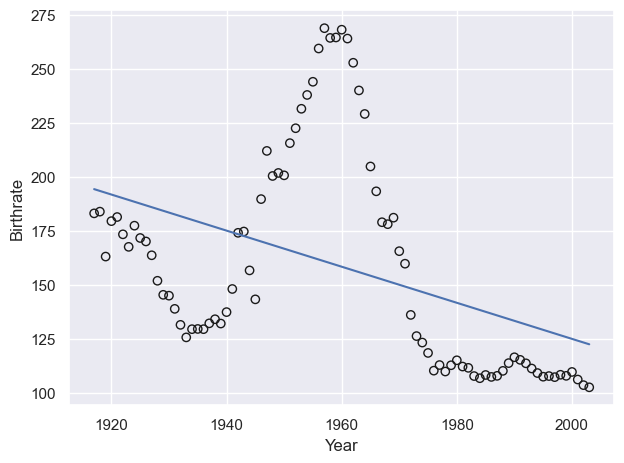

```python
url = "https://liangfgithub.github.io/Data/birthrates.csv"
birthrates = pd.read_csv(url, sep=',')
m, b = np.polyfit(birthrates['Year'], birthrates['Birthrate'], 1)
plt.scatter(x='Year', y='Birthrate', data=birthrates, fc='none', ec='k')
plt.plot(birthrates['Year'], m * birthrates['Year'] + b)
plt.xlabel('Year')
plt.ylabel('Birthrate')
plt.tight_layout()
```

### How does R Count DF

We can use `bs` or `ns` to generate the design matrix F.

You can either specify the location of knots directly or provide the desired degrees of freedom (df).

- The relationship between df and the number of knots is straightforward: for a cubic spline with m knots, the corresponding df is m+4.
- If you provide R with a df, it will determine the number of knots as df - 4.
- By default, knots are placed at quantiles. For instance, if three knots are required, they will be positioned at the 25th, 50th, and 75th percentiles.

However, The method (similar to R's method) of counting the df can be perplexing. In the commands, the term df actually denotes the number of columns in the design matrix returned by the command. If an intercept isn't included in the matrix (which is the default behavior), the df in the command will be the actual degree of freedom minus one.

Let's consider several commands to elucidate this.

- For a command specifying two knots at particular quantiles, this equates to 2+4=6 degrees of freedom. But since the intercept is typically omitted, this command would produce an n-by-5 design matrix.
- When the df is set to five (and no intercept included), the actual degrees of freedom become six. Hence, it would place two knots, typically at the 1/3 and 2/3 quantiles.

The subsequent code fit four spline models. Intriguingly, three of them are identical. The purpose is to help students comprehend how the degree of freedom is calculated.

```python
year = birthrates['Year']
y = birthrates['Birthrate']
X = bs(year, knots=np.quantile(year, [1/3, 2/3]))
fit1 = LinearRegression().fit(X, y).predict(X)

X = bs(year, df=5)
fit2 = LinearRegression().fit(X, y).predict(X)

X = bs(year, df=6, include_intercept=True)
fit3 = LinearRegression().fit(X, y).predict(X)

X = bs(year, df=5, include_intercept=True)
fit4 = LinearRegression().fit(X, y).predict(X)
```

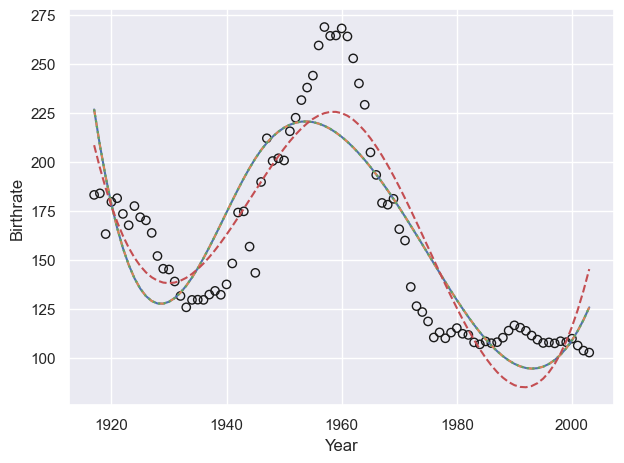

```python
plt.scatter(x='Year', y='Birthrate', data=birthrates, fc='none', ec='k')
plt.plot(year, interp1d(x=year, y=fit1)(year))
plt.plot(year, interp1d(x=year, y=fit2)(year), '--')
plt.plot(year, interp1d(x=year, y=fit3)(year), ':')
plt.plot(year, interp1d(x=year, y=fit4)(year), '--')
plt.xlabel('Year')
plt.ylabel('Birthrate')
plt.tight_layout()
```

For natural cubic splines, there's an intriguing detail to consider. Let's examine an interval [a, b] populated with knots represented as $\xi_1, \xi_2, \dots, \xi_m$.

The behavior of the functions at the two extreme intervals is uniquely determined by their neighboring functions. Specifically, the function spanning $[a, \xi_1]$ is governed by the behavior of the function within the interval $[\xi_1, \xi_2]$. Why is this the case?

Within the interval $[a, \xi_1]$, the function is linear and is determined by two parameters: its value and its 1st derivative at the boundary knot $\xi_1$. Due to the inherent continuity of spline functions (which preserves continuity up to the second derivative), both these parameters can be inferred from the function in the adjacent interval $[\xi_1, \xi_2]$.

A similar relationship is seen for the function in the $[\xi_m, b]$, which is shaped by the function's characteristics in the $[\xi_{m-1}, \xi_m]$ interval.

Hence, it's unnecessary to position data points in these outer intervals. By default, boundary knots are set to be $\xi_1$ and $\xi_m$ at the dataset's minimum and maximum values. And the option `knots` refers to interior knots.

```python
X = ns(year, knots=np.quantile(year, np.arange(1, 5) / 5))
fit1 = LinearRegression().fit(X, y).predict(X)

X = ns(year, df=5)
fit2 = LinearRegression().fit(X, y).predict(X)

X = ns(year, df=6, include_intercept=True)
fit3 = LinearRegression().fit(X, y).predict(X)
```

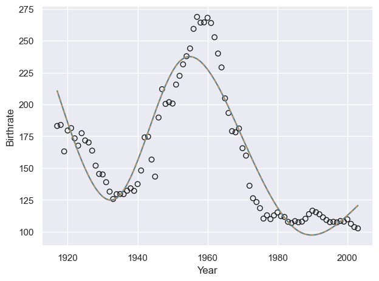

```python
plt.scatter(x='Year', y='Birthrate', data=birthrates, fc='none', ec='k')
plt.plot(year, interp1d(x=year, y=fit1)(year))
plt.plot(year, interp1d(x=year, y=fit2)(year), '--')
plt.plot(year, interp1d(x=year, y=fit3)(year), ':')
plt.xlabel('Year')
plt.ylabel('Birthrate')
plt.tight_layout()
```

### Prediction

Make prediction outside the data range.

```python
def bs_predict(new, x, df=None, knots=None, boundary_knots=None, degree=3, include_intercept=False):
    ord = 1 + degree

    if boundary_knots is None:
        boundary_knots = [np.min(x), np.max(x)]

    if df is not None:
        nIknots = df - ord + (1 - include_intercept)
        if nIknots < 0:
            nIknots = 0

        if nIknots > 0:
            knots = np.linspace(0, 1, num=nIknots + 2)[1:-1]
            knots = np.quantile(x, knots)

    basis = bs(new, df=df, knots=knots, boundary_knots=boundary_knots,
               degree=degree, include_intercept=include_intercept)

    return basis
```

```python
def ns_predict(new, x, df=None, knots=None, boundary_knots=None, include_intercept=False):
    degree = 3

    if boundary_knots is None:
        boundary_knots = [np.min(x), np.max(x)]
    else:
        boundary_knots = np.sort(boundary_knots).tolist()

    if df is not None:
        nIknots = df - 1 - include_intercept
        if nIknots < 0:
            nIknots = 0

        if nIknots > 0:
            knots = np.linspace(0, 1, num=nIknots + 2)[1:-1]
            knots = np.quantile(x, knots)

    basis = ns(new, df=df, knots=knots, boundary_knots=boundary_knots,
               include_intercept=include_intercept)

    return basis
```

```python
new = np.arange(1905, 2016)

X = bs(year, df=7)
X_new = bs_predict(new, year, df=7)
fit1 = LinearRegression().fit(X, y).predict(X_new)

X = ns(year, df=7)
X_new = ns_predict(new, year, df=7)
fit2 = LinearRegression().fit(X, y).predict(X_new)
```

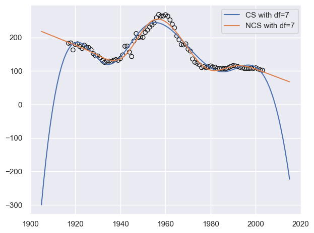

```python
plt.plot(new, interp1d(x=new, y=fit1)(new))
plt.plot(new, interp1d(x=new, y=fit2)(new))
plt.legend(["CS with df=7", "NCS with df=7"], loc="upper right")
plt.scatter(x='Year', y='Birthrate', data=birthrates, fc='none', ec='k')
plt.tight_layout()
```

## Select DF

The placement of knots significantly influences the performance of a spline model. However, handpicking the precise locations of these knots can be computationally burdensome. A more efficient strategy involves positioning the knots at quantiles of x, allowing us to focus solely on determining the optimal number of knots or, equivalently, the degrees of freedom (df).

Try cubic splines with different degree-of-freedoms

```python
X = bs(year, df=7)
fit1 = LinearRegression().fit(X, y).predict(X)

X = bs(year, df=14)
fit2 = LinearRegression().fit(X, y).predict(X)

X = bs(year, df=19)
fit3 = LinearRegression().fit(X, y).predict(X)
```

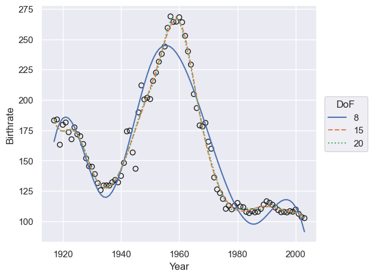

```python
plt.plot(year, interp1d(x=year, y=fit1)(year))
plt.plot(year, interp1d(x=year, y=fit2)(year), '--')
plt.plot(year, interp1d(x=year, y=fit3)(year), ':')
plt.legend([8, 15, 20], title="DoF",
           bbox_to_anchor=(1.01, 0.5), loc="center left")
plt.scatter(x='Year', y='Birthrate', data=birthrates, fc='none', ec='k')
plt.xlabel('Year')
plt.ylabel('Birthrate')
plt.tight_layout()
```

Recall that we use hypothesis testing to determine the optimal polynomial degree. The process involves iteratively increasing the polynomial degree. During each iteration, we utilize the t-test (which effectively acts as an F-test) to contrast two models: the current model and a bigger model with one degree more.

Can we utilize this same F-test approach to select the optimal number of knots in spline regression? The answer is "No." The primary reason being that the models being compared in this context are not nested. Consequently, the F-test, which relies on comparing nested models, is unsuitable for this specific purpose.

To address this, we employ 10-fold CV. We start with dividing the data into 10 folds.

```python
K = 10
n = birthrates.shape[0]
fold_size = np.concatenate(([9] * 7, [8] * 3))
fold_id = np.repeat(np.arange(0, K), fold_size)
fold_id
```

```
array([0, 0, 0, 0, 0, 0, 0, 0, 0, 1, 1, 1, 1, 1, 1, 1, 1, 1, 2, 2, 2, 2,
       2, 2, 2, 2, 2, 3, 3, 3, 3, 3, 3, 3, 3, 3, 4, 4, 4, 4, 4, 4, 4, 4,
       4, 5, 5, 5, 5, 5, 5, 5, 5, 5, 6, 6, 6, 6, 6, 6, 6, 6, 6, 7, 7, 7,
       7, 7, 7, 7, 7, 8, 8, 8, 8, 8, 8, 8, 8, 9, 9, 9, 9, 9, 9, 9, 9])
```

```python
fold_id = np.random.choice(fold_id, n)
fold_id
```

```
array([9, 0, 6, 6, 0, 0, 1, 2, 5, 3, 3, 6, 5, 0, 7, 6, 9, 2, 9, 2, 5, 1,
       5, 6, 7, 5, 1, 9, 1, 6, 7, 4, 6, 2, 2, 0, 7, 7, 1, 3, 9, 2, 5, 2,
       5, 2, 2, 3, 6, 9, 8, 2, 0, 4, 2, 0, 4, 5, 1, 9, 6, 1, 6, 8, 0, 3,
       1, 8, 1, 6, 5, 2, 5, 9, 3, 0, 0, 4, 3, 1, 5, 1, 1, 1, 4, 1, 6])
```

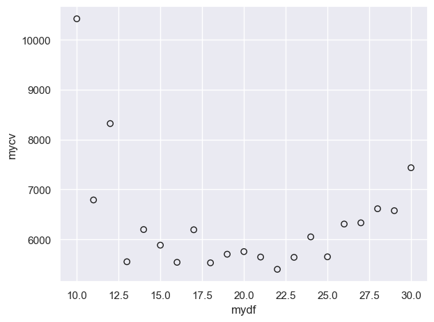

```python
mydf = np.arange(10, 31)
mycv = np.zeros(len(mydf))

for i in range(len(mydf)):
    m = mydf[i] - 4
    for k in range(K):
        mask = (fold_id == k)
        myknots = np.quantile(year[~mask], np.arange(1, m + 1) / (m + 1))
        myy = y[~mask].to_numpy()
        myX = bs(year[~mask], knots=myknots)
        myX_new = bs_predict(year[mask].to_numpy(),
                             year[~mask].to_numpy(), knots=myknots)
        myfit = LinearRegression().fit(myX, myy).predict(myX_new)
        mycv[i] += np.sum((myfit - y[mask]) ** 2.0)

plt.scatter(mydf, mycv, fc='none', ec='k')
plt.xlabel('mydf')
plt.ylabel('mycv')
plt.tight_layout()
```

```python
k = 0
mask = (fold_id == k)
myknots = np.quantile(year[~mask], np.arange(1, m + 1) / (m + 1))
myy = y[~mask].to_numpy()
myX = bs(year[~mask], knots=myknots)
myX_new = bs_predict(year[mask].to_numpy(),
                     year[~mask].to_numpy(), knots=myknots)
myfit = LinearRegression().fit(myX, myy).predict(myX_new)
mycv[i] += np.sum((myfit - y[mask]) ** 2.0)
```

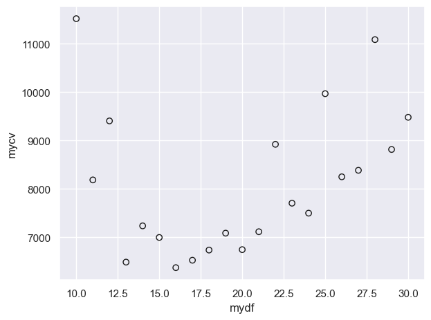

```python
fold_id = np.random.choice(fold_id, n)
fold_id

mydf = np.arange(10, 31)
mycv = np.zeros(len(mydf))

for i in range(len(mydf)):
    m = mydf[i] - 4
    for k in range(K):
        mask = (fold_id == k)
        myknots = np.quantile(year[~mask], np.arange(1, m + 1) / (m + 1))
        myy = y[~mask].to_numpy()
        myX = bs(year[~mask], knots=myknots)
        myX_new = bs_predict(year[mask].to_numpy(),
                             year[~mask].to_numpy(), knots=myknots)
        myfit = LinearRegression().fit(myX, myy).predict(myX_new)
        mycv[i] += np.sum((myfit - y[mask]) ** 2.0)

plt.scatter(mydf, mycv, fc='none', ec='k')
plt.xlabel('mydf')
plt.ylabel('mycv')
plt.tight_layout()
```